# Recreational Spaces and Health Outcomes Across Victoria

Nana Cheng, Kaiyi Ye, Jingyi Wang

21 October 2026

## Why Does Recreational Accessibility Matter?

**Does access to recreational spaces help explain differences in health?**

- Parks, natural areas and sports facilities provide opportunities for physical activity.
- Access to these spaces varies across communities in Victoria.
- Socioeconomic conditions and population density may also help explain differences in physical activity and health outcomes.

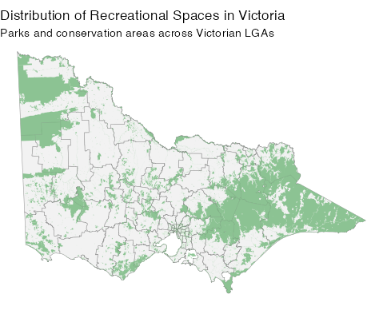

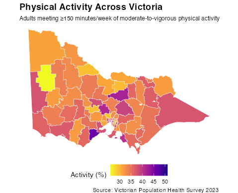

## Research Questions

### Main Research Question

Does recreational accessibility explain additional variation in physical activity and health outcomes across Victoria, beyond socioeconomic conditions and population density?

### Specific Questions

1. How much variation is explained by socioeconomic conditions and population density?
2. Does adding recreational accessibility improve model fit?
3. Which accessibility dimensions provide the greatest additional explanatory power?

## Study Area & Data Sources

**79 Local Government Areas**

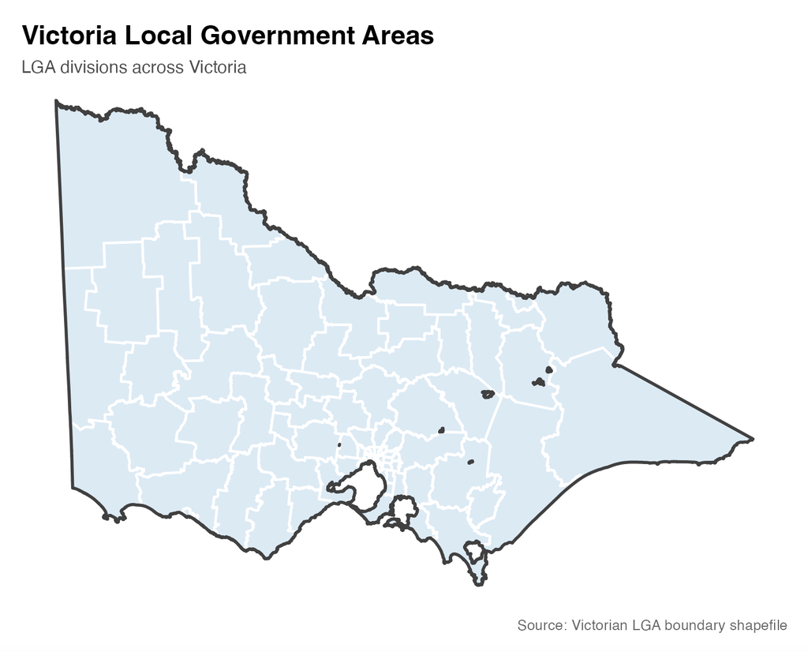

### Data Sources

**Health Data**

- Physical activity and health outcomes
- Source: Victorian Department of Health (2023)

**Socioeconomic & Population Data**

- SEIFA, population and Mesh Blocks
- Source: Australian Bureau of Statistics

**Spatial & Recreational Data**

- Parks, natural areas and LGA boundaries
- Source: Department of Transport and Planning
- Sports and recreational facilities
- Source: Department of Jobs, Skills, Industry and Regions

## Key Variables

### Socioeconomic & Demographic Characteristics

**Socioeconomic Conditions**

- SEIFA IRSAD (2021)
- Relative advantage and disadvantage

**Population Density**

- People per km² (2023)

### Recreational Accessibility

**Distance-based Measures**

- Nearest park
- Nearest natural area
- Nearest recreational facility
- Nearest indoor facility

**Facility-based Measures**

- Indoor facilities (%)
- Sport types available

### Physical Activity & Health

**Physical Activity**

- Inactivity(did not do any moderate to vigorous physical activity)
- Activity (≥150 min/week of moderate to vigorous physical activity)

**Health Outcomes**

- Obesity (BMI ≥30)
- High psychological distress
- Fair/poor self-rated health

## How Do We Measure Recreational Accessibility?

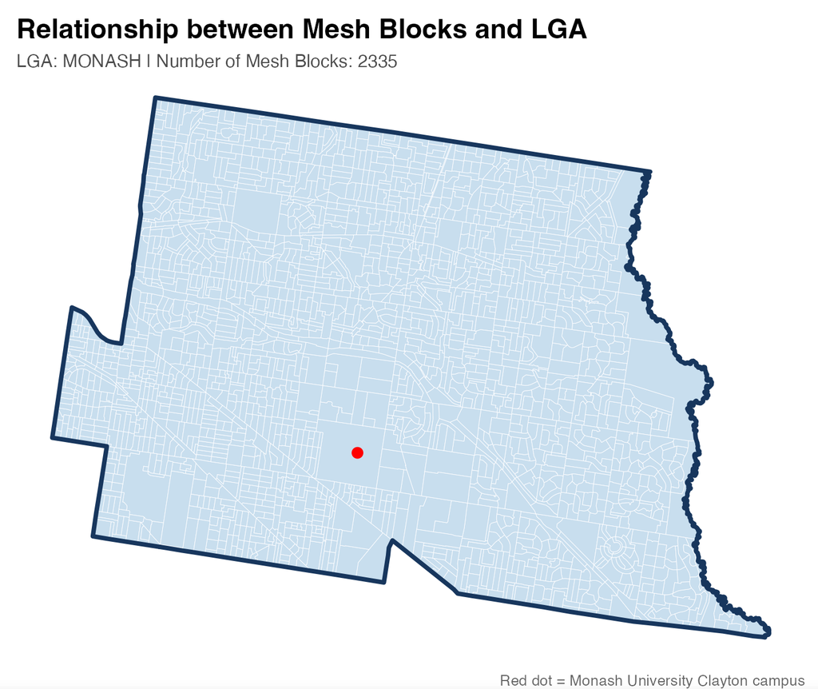

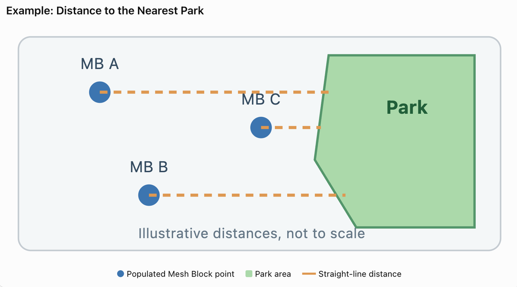

### Step 1: Locate Residents

- Use populated 2021 Census Mesh Blocks
- Represent residents using a point within each Mesh Block

### Step 2: Measure Distances

- Straight-line distance to the nearest recreational destination
- Parks, natural areas, recreational and indoor facilities

### Step 3: Aggregate

- Weight distances by Mesh Block population
- Calculate the population-weighted median for each LGA

## Exploring the Data

## Recreational Accessibility Varies Across Victoria

### Parks

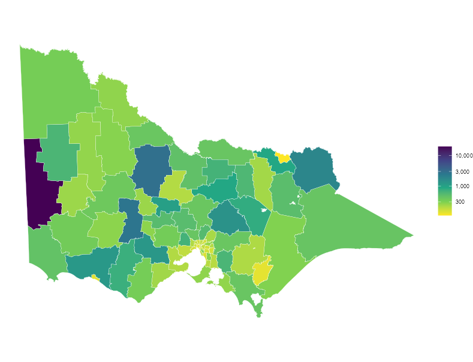

### Facilities

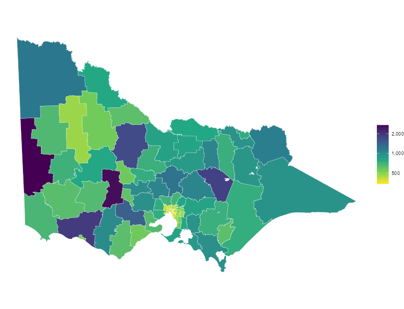

### Natural areas

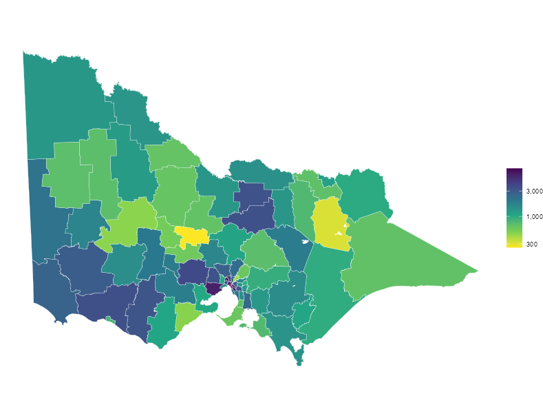

Darker colours indicate longer distances (poorer accessibility).

Recreational accessibility varies substantially across Victorian LGAs, with different spatial patterns across recreational space types.

## Health Outcomes Also Vary Across Victoria

### Inactivity

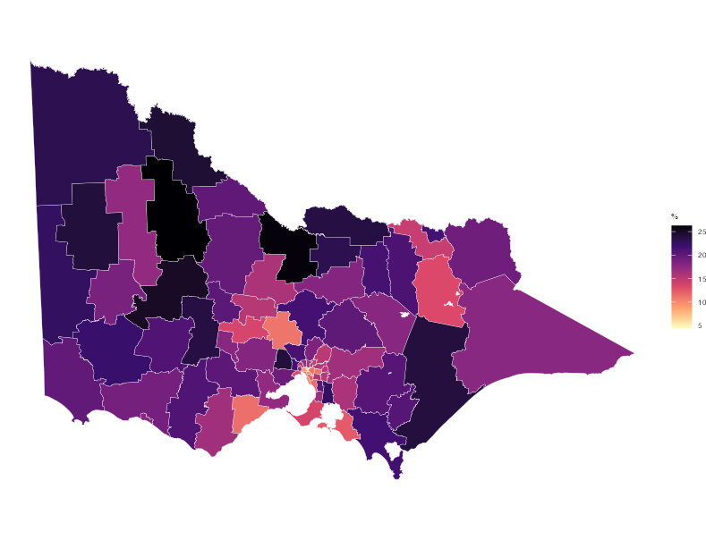

### Activity

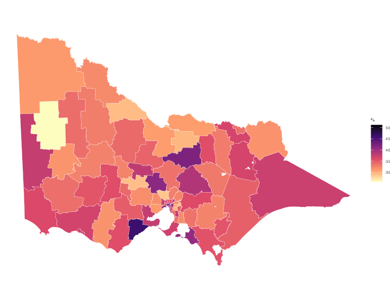

### Obesity

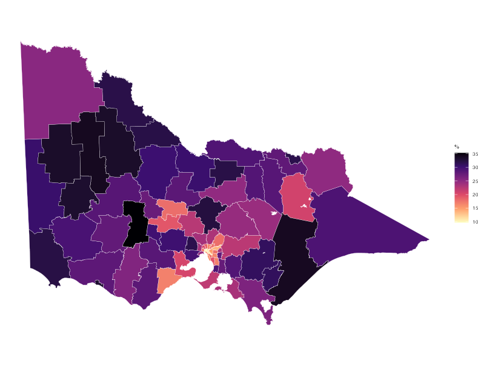

Health outcomes also differ across Victorian LGAs.

**Next:** Is there a relationship between recreational accessibility and health outcomes?

## How Is Recreational Accessibility Related to Health Outcomes?

Four selected relationships highlighting clearer associations and different patterns.

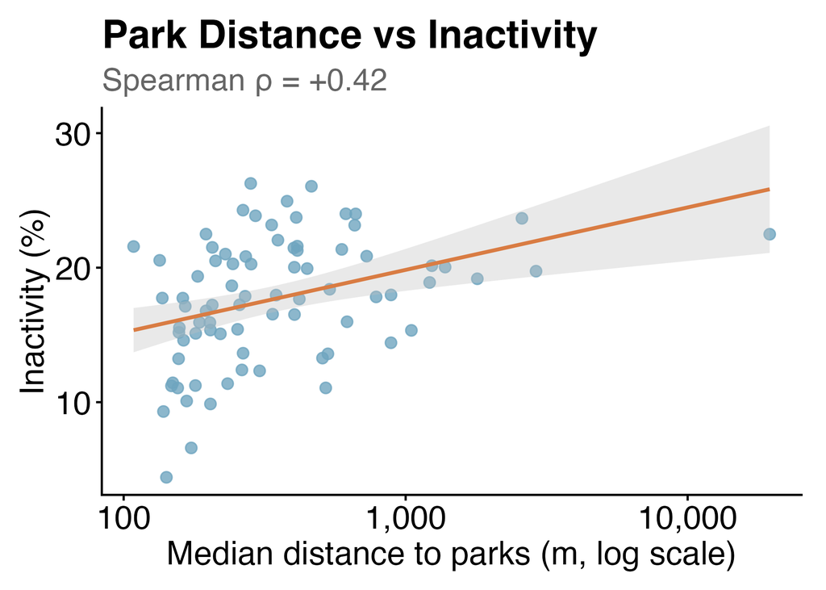

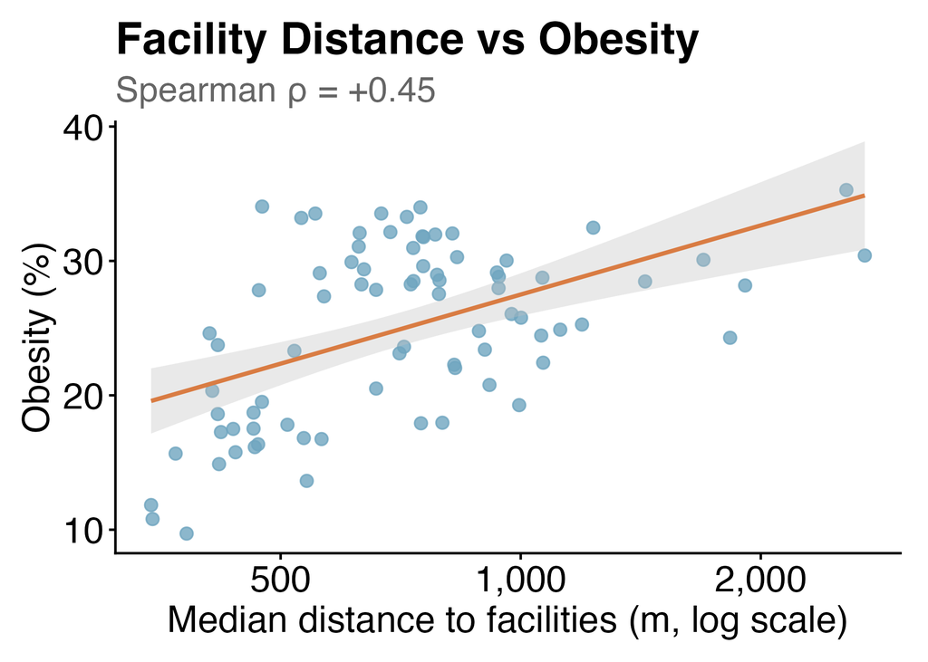

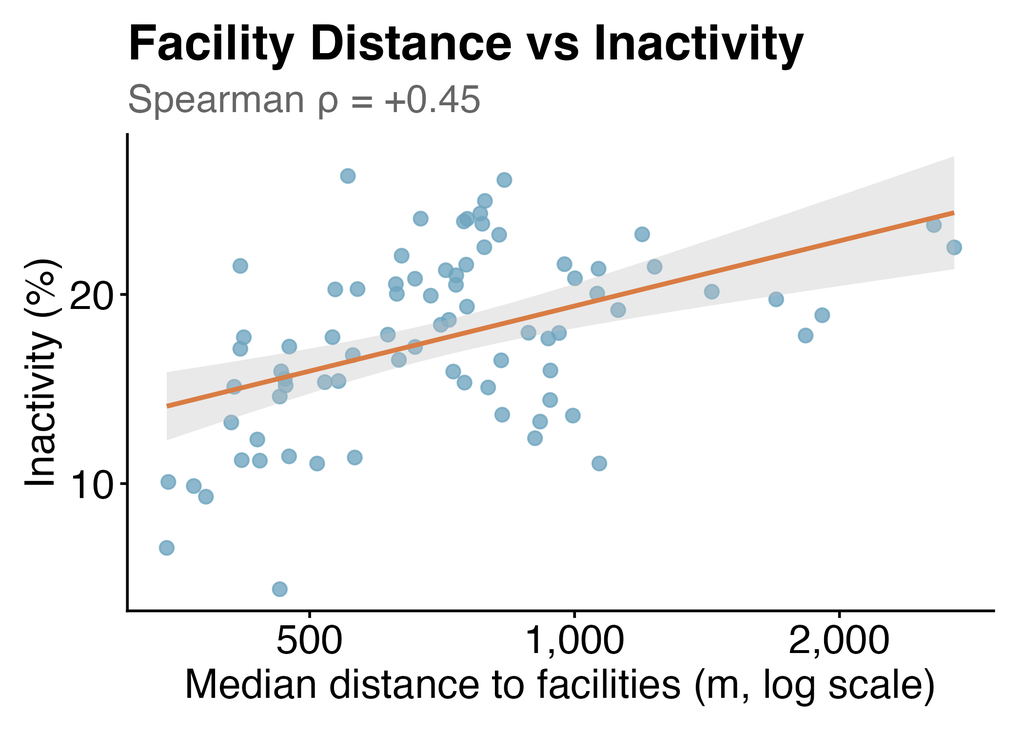

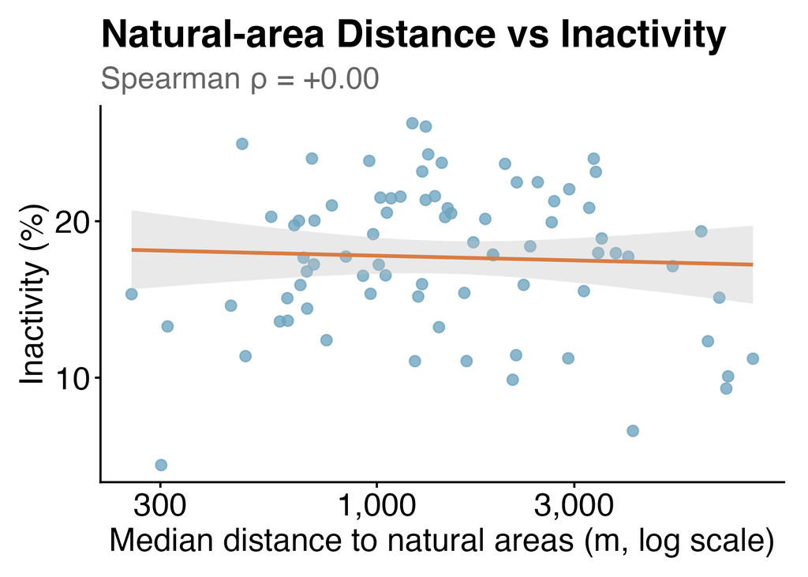

#### Positive associations

Longer park and facility distances tend to be associated with higher inactivity and obesity.

#### Different pattern

Natural-area distance has almost no unadjusted correlation with inactivity.

#### Variation between LGAs

Similar accessibility does not always mean similar health outcomes.

**Next:** What other factors might help explain these patterns?

## Socioeconomic Conditions Are Related to Access and Health

#### SEIFA vs accessibility

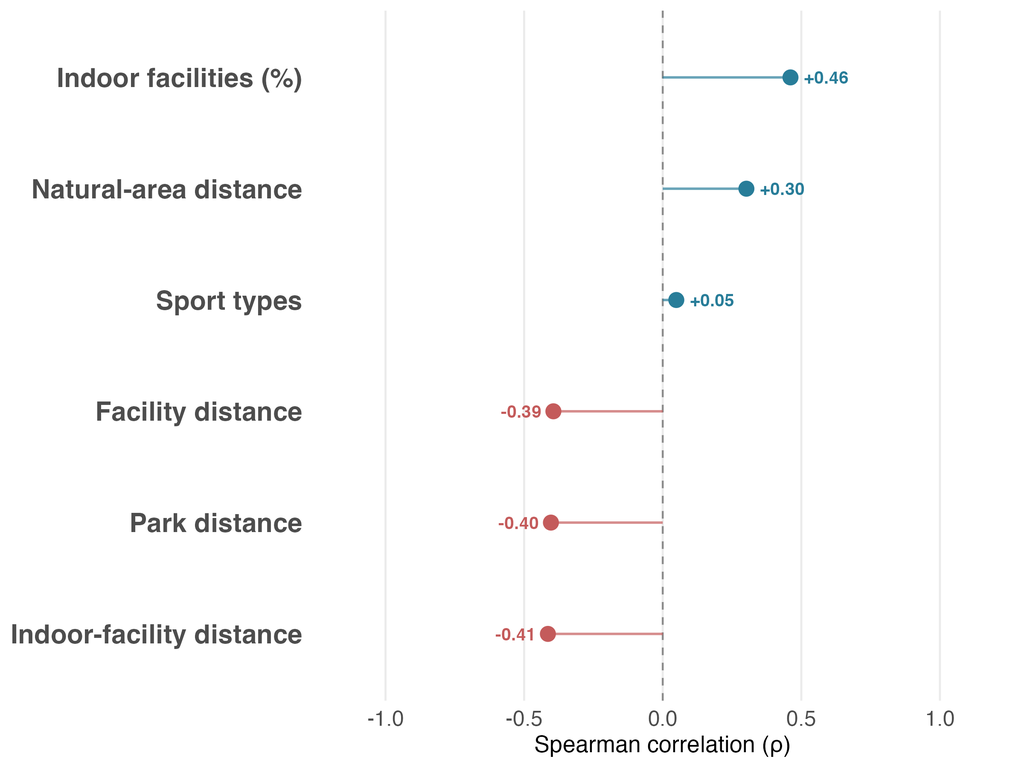

More advantaged LGAs: closer to parks and recreational facilities, but further from natural areas.

#### SEIFA vs health outcomes

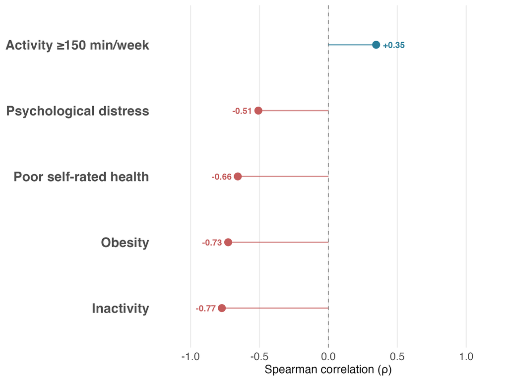

More advantaged LGAs: lower inactivity, obesity, psychological distress and poor self-rated health.

## Population Density Is Also Linked to Access and Health

#### Population Density vs Accessibility

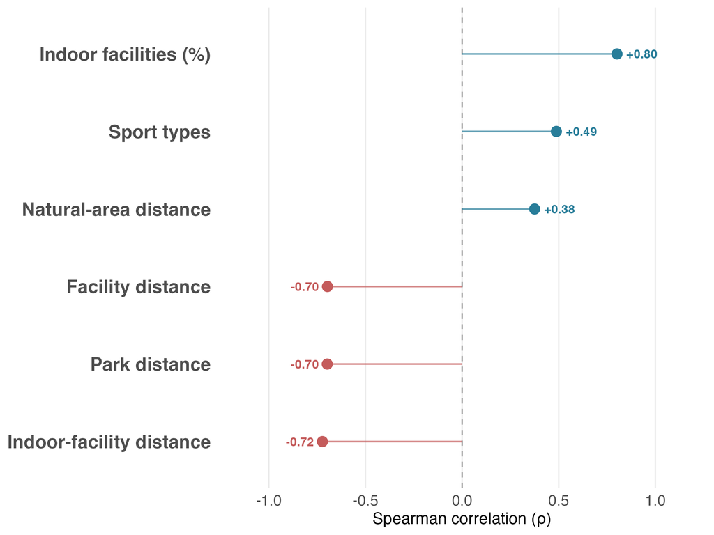

#### Population Density vs Health Outcomes

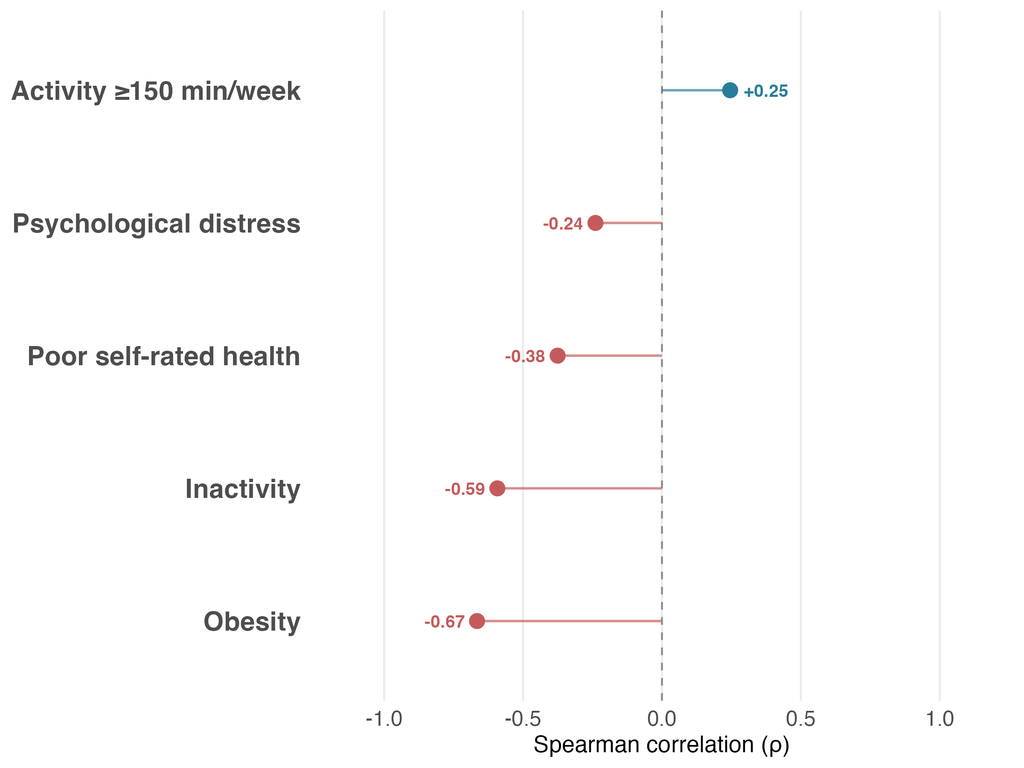

**Similar to SEIFA,** denser LGAs tend to be closer to parks and facilities, and have better outcomes across several health measures, particularly inactivity and obesity.

Both SEIFA and population density may partly explain the relationships observed between accessibility and health outcomes.

## Accessibility Indicators Are Related but Not Identical

#### Correlations among 6 access indicators

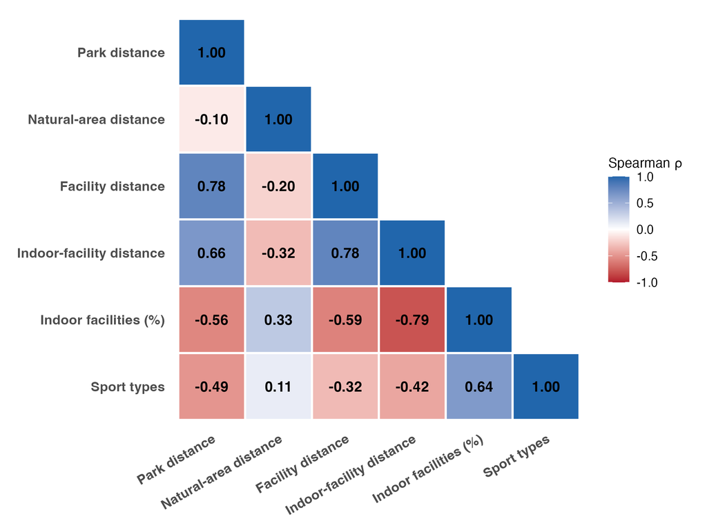

### Strong correlations

**Park vs facility distance:** ρ = +0.78

**Facility vs indoor distance:** ρ = +0.78

These measures provide similar information.

### Distinct pattern

**Natural-area distance:** Much weaker correlations with the others.

It tells us something different.

## What Have We Found So Far?

### 1. Accessibility has different dimensions

Accessibility varies across LGAs. Some indicators show similar patterns, while others provide different information.

### 2. Associations differ across outcomes

Longer park and facility distances tend to be linked to higher inactivity and obesity, but not all accessibility measures show the same pattern.

### 3. Broader LGA characteristics matter

SEIFA and population density are related to both accessibility and health outcomes.

**Next:** Does recreational accessibility explain additional variation in health outcomes beyond SEIFA and population density?

## Regression Modelling

## Our Modelling Strategy

M0 → M1

Baseline models

M0: SEIFA

M1: SEIFA + population density

M2

Individual accessibility models

SEIFA + population density + only one accessibility indicator

A / B / C

Combined accessibility models

A: SEIFA + population density + park–facility distance + natural-area distance + indoor-facility distance

B: SEIFA + population density + park distance + facility distances + natural-area distance + indoor-facility distances

C: SEIFA + population density + park distance + facility distances + natural-area distance + indoor-facility distances + Indoor facilities (%) + sport-type count

How did we evaluate the models?

Adjusted R² for explanatory power, HC3 robust tests for statistical evidence, and diagnostic checks for reliability.

## Main Results

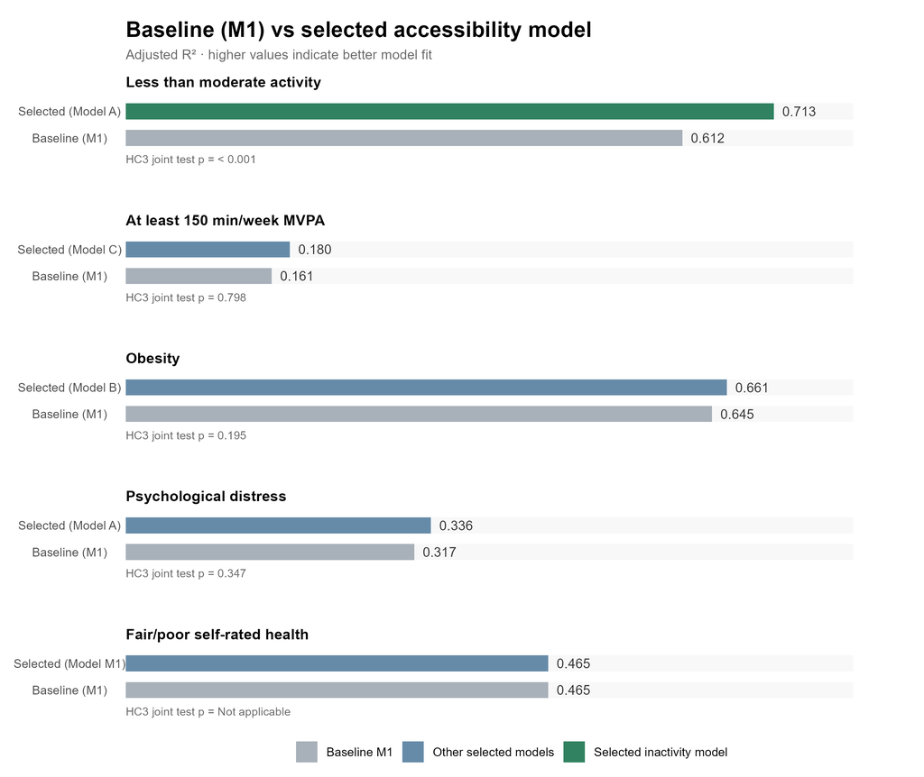

**Main finding**

- Adding recreational accessibility (Selected Model A) significantly improved the explanatory power for inactivity (Adjusted $R^2$ increased from 0.612 to 0.713, $\Delta R^2 \approx 0.10$, HC3 joint test $p < 0.001$).
- For all other health outcomes (MVPA, obesity, psychological distress), adding accessibility indicators did not yield statistically significant improvements over the baseline model ($p>0.05$).

## What is associated with inactivity (less than moderate activity)?

**Selected Model A · outcome measured in percentage points**

Model A : SEIFA + population density + park-facility distance + natural-area distance + indoor-facility distance

$$\begin{aligned}
\widehat{\text{Inactivity}}_i \text{ (\%)} ={} & 17.695 \\
& - 3.717\,\text{z\_seifa}_i \\
& - 0.542\,\text{z\_density}_i \\
& + 1.154\,\text{z\_parkfac}_i \\
& + 1.119\,\text{z\_nature}_i \\
& - 1.290\,\text{z\_indoor}_i
\end{aligned}$$

where $\mathtt{z\_parkfac}_i = \frac{\mathtt{z\_park}_i + \mathtt{z\_facility}_i}{2}$, and $\varepsilon_i$ is the error term.

| Predictor | Coefficient (95% HC3 CI) |
| --- | --- |
| SEIFA | -3.717 [-4.597, -2.836] |
| Population denisty | -0.542 [-1.827, 0.743] |
| Park/facility distance | +1.154 [+0.343, +1.964] |
| Natural-area distance | +1.119 [+0.433, +1.804] |
| Indoor-facility distance | -1.290 [-2.159, -0.421] |

## Interpretation & Robustness - Inactivity (Model A)

📈 1. Socioeconomic advantage matters

β = −3.717

Higher SEIFA was associated with lower inactivity in Model A (95% CI: −4.597 to −2.836).

🌱 2. Accessibility is associated with inactivity

Greater park/facility distance (β = 1.154) and natural-area distance (β = 1.119) were associated with higher inactivity.

Conversely, living further from indoor facilities was associated with lower inactivity (β = −1.290).

Model checks & Robustness

**📊 3. Regression diagnostics** Adj. $R^2$ = 0.713, $\Delta R^2$ = 0.100 over baseline. No severe multicollinearity was detected (max VIF = 3.98). HC3 joint test $p < 0.001$.

**✅ 4. Robustness (Leave-one-LGA-out)** The model fit remained highly stable across all leave-one-LGA-out checks (Adj. $R^2$ ranged from 0.688 to 0.735).

## Discussion

RQ1 — Baseline explanatory power

- SEIFA and population density explained different patterns across health outcomes.

RQ2 — Does accessibility add explanatory power?

- **Inactivity: yes**. Clear additional explanatory value.
- **Activity, obesity and psychological distress:** Adjusted R² improved only slightly, with no significant HC3 joint contribution.
- **Fair/poor self-rated health:** Accessibility did not improve the selected model.

RQ3 — Which dimensions matter?

- Different accessibility measures showed different associations with inactivity.
- No single accessibility dimension was consistently important across all outcomes.

## Limitations

- **LGA-level analysis**

Results describe area-level patterns, not individual behaviour.

- **Cross-sectional data**

The data capture variables at a single point in time, so the analysis can only identify associations between variables and cannot establish causal effects or capture changes over time.

- **Accessibility measures**

Straight-line distance does not capture actual travel time, facility quality, affordability, opening hours or personal preferences.

## Conclusion

**Main question:** Does recreational accessibility help explain differences in physical activity and health outcomes across Victorian LGAs, beyond socioeconomic advantage and population density?

- **Yes, for inactivity:** Accessibility added significant explanatory value beyond socioeconomic advantage and population density.
- **Not consistently for other outcomes:** The additional explanatory value was limited, and the findings show associations rather than causal effects.

Overall, accessibility appeared **more informative for inactivity than for the other health outcomes examined**.

## Thank You!

### Questions & Discussion

Recreational Spaces and Health Outcomes Across Victoria

Nana Cheng · Kaiyi Ye · Jingyi Wang